runfile('C:/Users/pfeif/Documents/_Projects/Network Sediment Transporter/Running the NST/NST_sedpulse.py', wdir='C:/Users/pfeif/Documents/_Projects/Network Sediment Transporter/Running the NST')

In [138]:

In [138]: measuretime.time() - start_time

Out[138]: 336.5291860103607

In [139]: print('Elapsed:', measuretime.time() - start_time ,' seconds')

Elapsed: 376.3334336280823 seconds

In [140]: runfile('C:/Users/pfeif/Documents/_Projects/Network Sediment Transporter/Running the NST/NST_sedpulse.py', wdir='C:/Users/pfeif/Documents/_Projects/Network Sediment Transporter/Running the NST')

Model time: 0.0 hours passed

Elapsed: 3.3642664591471356 minutes

Model time: 4.0 hours passed

Elapsed: 5.128075428803762 minutes

Model time: 8.0 hours passed

Elapsed: 3.6237976908683778 minutes

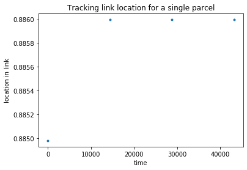

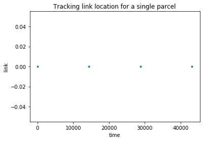

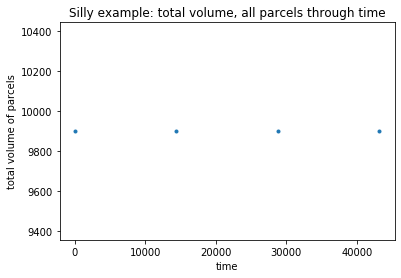

In [141]: plt.plot(parcels.time_coordinates, parcels.dataset.location_in_link.values[999, :], ".")

Out[141]: [<matplotlib.lines.Line2D at 0x148397462b0>]

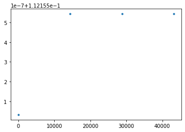

In [142]: plt.plot(parcels.time_coordinates, parcels.dataset.active_layer.values[999, :], ".")

Out[142]: [<matplotlib.lines.Line2D at 0x1483ae764e0>]

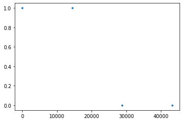

In [143]: runfile('C:/Users/pfeif/Documents/_Projects/Network Sediment Transporter/Running the NST/NST_sedpulse.py', wdir='C:/Users/pfeif/Documents/_Projects/Network Sediment Transporter/Running the NST')

Model time: 0.0 hours passed

Elapsed: 3.6002476731936137 minutes

Model time: 4.0 hours passed

Elapsed: 4.767919647693634 minutes

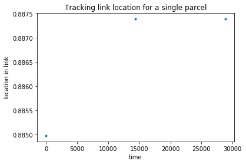

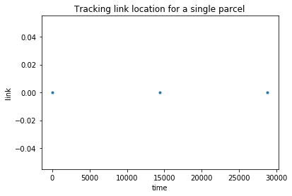

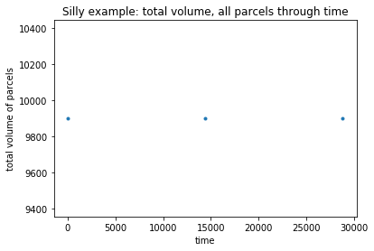

In [144]: plt.plot(parcels.time_coordinates, parcels.dataset.active_layer.values[0, :], ".")

Out[144]: [<matplotlib.lines.Line2D at 0x1483ae6f208>]

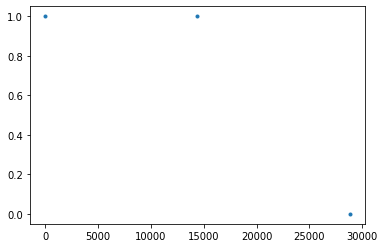

In [145]: runfile('C:/Users/pfeif/Documents/_Projects/Network Sediment Transporter/Running the NST/NST_sedpulse.py', wdir='C:/Users/pfeif/Documents/_Projects/Network Sediment Transporter/Running the NST')

Model time: 0.0 hours passed

Elapsed: 3.2917389909426373 minutes

Model time: 4.0 hours passed

Elapsed: 3.2655372420946756 minutes

Model time: 8.0 hours passed

Elapsed: 3.965836783250173 minutes

runfile('C:/Users/pfeif/Documents/_Projects/Network Sediment Transporter/Running the NST/NST_sedpulse.py', wdir='C:/Users/pfeif/Documents/_Projects/Network Sediment Transporter/Running the NST')

execfile(filename, namespace)

exec(compile(f.read(), filename, 'exec'), namespace)

nst.run_one_step(dt)

ValueError: NST Channel Slope Negative

In [146]:

In [146]: nst.grid.at_link["topographic__elevation"]

nst.grid.at_link["topographic__elevation"]

FieldError: topographic__elevation

In [147]:

In [147]: nst.grid.at_link["channel_slope"]

Out[147]:

array([ 0.0084898 , 0.01 , 0.0102449 , 0.00991837, 0.00991837,

0.00983673, 0.0102449 , 0.00983673, 0.01012245, 0.01 ,

0.00987755, 0.01008163, 0.00987755, 0.01012245, 0.0097551 ,

0.01036735, 0.00979592, 0.01008163, 0.00983673, 0.01016327,

0.01012245, 0.00991837, 0.01008163, 0.01004082, 0.00959184,

0.01004082, 0.01020408, 0.01012245, 0.0097551 , 0.01016327,

0.00979592, 0.01016327, 0.0104898 , 0.00930612, 0.01012245,

0.00979592, 0.01036735, 0.00991837, 0.00995918, 0.00995918,

0.01008163, 0.00995918, 0.01004082, 0.01016327, 0.01 ,

0.01 , 0.00971429, 0.01 , 0.01008163, 0.00995918,

0.01 , 0.01032653, 0.0097551 , 0.01 , 0.00991837,

0.01008163, 0.00991837, 0.01012245, 0.00979592, 0.01032653,

0.00979592, 0.00987755, 0.01020408, 0.00983673, 0.01008163,

0.01020408, 0.00987755, 0.01 , 0.00995918, 0.00991837,

0.00995918, 0.01008163, 0.00991837, 0.01028571, 0.00983673,

0.00983673, 0.01032653, 0.00979592, 0.01004082, 0.00995918,

0.01 , 0.01 , 0.01004082, 0.00987755, 0.01012245,

0.01 , 0.01 , 0.01 , 0.01004082, 0.00987755,

0.01008163, 0.01016327, 0.00983673, 0.01 , 0.01 ,

0.01012245, 0.00987755, 0.00995918, 0.00244898])

In [148]: plt.plot(nst.grid.at_link["channel_slope"])

Out[148]: [<matplotlib.lines.Line2D at 0x14837d6cf98>]

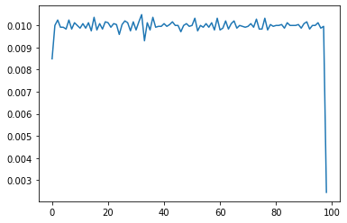

In [149]: nst._parcels.dataset.volume[-1,:].values

...:

Out[149]: array([ 1., 1., 1., 1., 1.])

In [150]: Parcels = nst._parcels.dataset.element_id.values

In [151]: length(Parcels == 99)

length(Parcels == 99)

NameError: name 'length' is not defined

In [152]:

In [152]: np.size(Parcels == 99)

Out[152]: 49500

In [153]: np.size(Parcels(Parcels== 99))

np.size(Parcels(Parcels== 99))

TypeError: 'numpy.ndarray' object is not callable

In [154]:

In [154]: Parcels[Parcels==99]

Out[154]: array([], dtype=float64)

In [155]: Parcels[Parcels==98]

Out[155]:

98., 98., 98., 98., 98., 98., 98., 98., 98., 98., 98.,

98., 98., 98., 98., 98., 98., 98., 98., 98., 98., 98.,

98., 98., 98., 98., 98., 98., 98., 98., 98., 98., 98.,

98., 98., 98., 98., 98., 98., 98., 98., 98., 98., 98.,

98., 98., 98., 98., 98., 98., 98., 98., 98., 98., 98.,

98., 98., 98., 98., 98., 98., 98., 98., 98., 98., 98.,

98., 98., 98., 98., 98., 98., 98., 98., 98., 98., 98.,

98., 98., 98., 98., 98., 98., 98., 98., 98., 98., 98.,

98., 98., 98., 98., 98., 98., 98., 98., 98., 98., 98.,

98., 98., 98., 98., 98., 98., 98., 98., 98., 98., 98.,

98., 98., 98., 98., 98., 98., 98., 98., 98., 98., 98.,

98., 98., 98., 98., 98., 98., 98., 98., 98., 98., 98.,

98., 98., 98., 98., 98., 98., 98., 98., 98., 98., 98.,

98., 98., 98., 98., 98., 98., 98., 98., 98., 98., 98.,

98., 98., 98., 98., 98., 98., 98., 98., 98., 98., 98.,

98., 98., 98., 98., 98., 98., 98., 98., 98., 98., 98.,

98., 98., 98., 98., 98., 98., 98., 98., 98., 98., 98.,

98., 98., 98., 98., 98., 98., 98., 98., 98., 98., 98.,

98., 98., 98., 98., 98., 98., 98., 98., 98., 98., 98.,

98., 98., 98., 98., 98., 98., 98., 98., 98., 98., 98.,

98., 98., 98., 98., 98., 98., 98., 98., 98., 98., 98.,

98., 98., 98., 98., 98., 98., 98., 98., 98., 98., 98.,

98., 98., 98., 98., 98., 98., 98., 98., 98., 98., 98.,

98., 98., 98., 98., 98., 98., 98., 98., 98., 98., 98.,

98., 98., 98., 98., 98., 98., 98., 98., 98., 98., 98.,

98., 98., 98., 98., 98., 98., 98., 98., 98., 98., 98.,

98., 98., 98., 98., 98., 98., 98., 98., 98., 98., 98.,

98., 98., 98., 98., 98., 98., 98., 98., 98., 98., 98.,

98., 98., 98., 98., 98., 98., 98., 98., 98., 98., 98.,

98., 98., 98., 98., 98., 98., 98., 98., 98., 98., 98.,

98., 98., 98., 98., 98., 98., 98., 98., 98., 98., 98.,

98., 98., 98., 98., 98., 98., 98., 98., 98., 98., 98.,

98., 98., 98., 98., 98., 98., 98., 98., 98., 98., 98.,

98., 98., 98., 98., 98., 98., 98., 98., 98., 98., 98.,

98., 98., 98., 98., 98., 98., 98., 98., 98., 98., 98.,

In [156]: np.size(Parcels[Parcels==98])

Out[156]: 502

In [157]: Parcels = []

In [158]: Parcels.append = nst._parcels.dataset.element_id[:,0].values

File "<ipython-input-158-49f90f66f2ce>", line 1, in <module>

Parcels.append = nst._parcels.dataset.element_id[:,0].values

AttributeError: 'list' object attribute 'append' is read-only

In [159]:

In [159]: Parcels.append(np.size(nst._parcels.dataset.element_id[:,0].values))

...:

In [160]: filler = np.size(nst._parcels.dataset.element_id[:,0].values)

In [161]: Parcels.append(np.size(filler(filler==98)))

File "<ipython-input-161-ca3b79db85e8>", line 1, in <module>

Parcels.append(np.size(filler(filler==98)))

TypeError: 'int' object is not callable

In [162]:

In [162]: filler =(nst._parcels.dataset.element_id[:,0].values)

In [163]: Parcels.append(np.size(filler(filler==98)))

File "<ipython-input-163-ca3b79db85e8>", line 1, in <module>

Parcels.append(np.size(filler(filler==98)))

TypeError: 'numpy.ndarray' object is not callable

In [164]:

In [164]: filler

Out[164]: array([ 0., 0., 0., ..., 98., 98., 98.])

In [165]: Parcels.append(np.size(filler[filler==98]))

In [166]: parcels[0]=[]

File "<ipython-input-166-406dfb4e427a>", line 1, in <module>

parcels[0]=[]

TypeError: 'DataRecord' object does not support item assignment

In [167]:

In [167]: Parcels[0]=[]

In [168]: filler =(nst._parcels.dataset.element_id[:,1].values)

In [169]: Parcels.append(np.size(filler[filler==98]))

In [170]: filler =(nst._parcels.dataset.element_id[:,2].values)

In [171]: Parcels.append(np.size(filler[filler==98]))

In [172]: filler =(nst._parcels.dataset.element_id[:,3].values)

In [173]: Parcels.append(np.size(filler[filler==98]))

In [174]: filler =(nst._parcels.dataset.element_id[:,4].values)

In [175]: Parcels.append(np.size(filler[filler==98]))

In [176]: filler =(nst._parcels.dataset.element_id[:,5].values)

File "<ipython-input-176-566187d46c61>", line 1, in <module>

filler =(nst._parcels.dataset.element_id[:,5].values)

IndexError: index 5 is out of bounds for axis 0 with size 5

In [177]:

In [177]: nst._grid.at_node["topographic__elevation"]

Out[177]:

array([ 101. , 100.15102041, 99.15102041, 98.12653061,

97.13469388, 96.14285714, 95.15918367, 94.13469388,

93.15102041, 92.13877551, 91.13877551, 90.15102041,

89.14285714, 88.15510204, 87.14285714, 86.16734694,

85.13061224, 84.15102041, 83.14285714, 82.15918367,

81.14285714, 80.13061224, 79.13877551, 78.13061224,

77.12653061, 76.16734694, 75.16326531, 74.14285714,

73.13061224, 72.15510204, 71.13877551, 70.15918367,

69.14285714, 68.09387755, 67.16326531, 66.15102041,

65.17142857, 64.13469388, 63.14285714, 62.14693878,

61.15102041, 60.14285714, 59.14693878, 58.14285714,

57.12653061, 56.12653061, 55.12653061, 54.15510204,

53.15510204, 52.14693878, 51.15102041, 50.15102041,

49.11836735, 48.14285714, 47.14285714, 46.15102041,

45.14285714, 44.15102041, 43.13877551, 42.15918367,

41.12653061, 40.14693878, 39.15918367, 38.13877551,

37.15510204, 36.14693878, 35.12653061, 34.13877551,

33.13877551, 32.14285714, 31.15102041, 30.15510204,

29.14693878, 28.15510204, 27.12653061, 26.14285714,

25.15918367, 24.12653061, 23.14693878, 22.14285714,

21.14693878, 20.14693878, 19.14693878, 18.14285714,

17.15510204, 16.14285714, 15.14285714, 14.14285714,

13.14285714, 12.13877551, 11.15102041, 10.14285714,

9.12653061, 8.14285714, 7.14285714, 6.14285714,

5.13061224, 4.14285714, 3.14693878, 3.29387755])

In [178]: runfile('C:/Users/pfeif/Documents/_Projects/Network Sediment Transporter/Running the NST/NST_sedpulse.py', wdir='C:/Users/pfeif/Documents/_Projects/Network Sediment Transporter/Running the NST')

Model time: 0.0 hours passed

Elapsed: 2.3409353772799175 minutes

*(taustar-0.0549)**0.56)

Model time: 4.0 hours passed

Elapsed: 2.369162627061208 minutes

*(taustar-0.0549)**0.56)

Model time: 8.0 hours passed

Elapsed: 2.9934539953867594 minutes

*(taustar-0.0549)**0.56)

Model time: 12.0 hours passed

Elapsed: 2.657753797372182 minutes

*(taustar-0.0549)**0.56)

Model time: 16.0 hours passed

Elapsed: 3.397978695233663 minutes

*(taustar-0.0549)**0.56)

Model time: 20.0 hours passed

Elapsed: 2.5761123577753704 minutes

*(taustar-0.0549)**0.56)

Model time: 24.0 hours passed

Elapsed: 2.793020073572795 minutes

*(taustar-0.0549)**0.56)

Model time: 28.0 hours passed

Elapsed: 2.679477270444234 minutes

*(taustar-0.0549)**0.56)

Model time: 32.0 hours passed

Elapsed: 2.9160441319147745 minutes

*(taustar-0.0549)**0.56)

Model time: 36.0 hours passed

Elapsed: 3.7546265800793965 minutes

*(taustar-0.0549)**0.56)

Model time: 40.0 hours passed

Elapsed: 3.6988988280296327 minutes

*(taustar-0.0549)**0.56)

Model time: 44.0 hours passed

Elapsed: 3.6144636193911235 minutes

*(taustar-0.0549)**0.56)

Model time: 48.0 hours passed

Elapsed: 3.795520015557607 minutes

*(taustar-0.0549)**0.56)

Model time: 52.0 hours passed

Elapsed: 3.8600127895673118 minutes

*(taustar-0.0549)**0.56)

Model time: 56.0 hours passed

Elapsed: 3.7560941139856974 minutes

*(taustar-0.0549)**0.56)

Model time: 60.0 hours passed

Elapsed: 3.7688023924827574 minutes

*(taustar-0.0549)**0.56)

Model time: 64.0 hours passed

Elapsed: 3.9594846765200296 minutes

*(taustar-0.0549)**0.56)

Model time: 68.0 hours passed

Elapsed: 4.013121088345845 minutes

*(taustar-0.0549)**0.56)

Model time: 72.0 hours passed

Elapsed: 3.8567729512850444 minutes

*(taustar-0.0549)**0.56)

Model time: 76.0 hours passed

Elapsed: 3.657043178876241 minutes

*(taustar-0.0549)**0.56)

Model time: 80.0 hours passed

Elapsed: 4.060780882835388 minutes

*(taustar-0.0549)**0.56)

Model time: 84.0 hours passed

Elapsed: 3.4366209149360656 minutes

*(taustar-0.0549)**0.56)

Model time: 88.0 hours passed

Elapsed: 3.8614399512608846 minutes

*(taustar-0.0549)**0.56)

Model time: 92.0 hours passed

Elapsed: 4.1777470509211225 minutes

*(taustar-0.0549)**0.56)

Model time: 96.0 hours passed

Elapsed: 3.9135737498601277 minutes

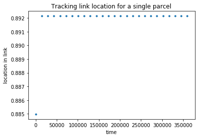

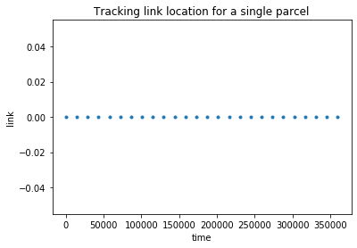

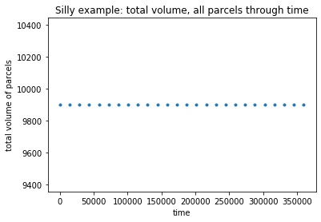

In [179]: plt.plot(parcels.time_coordinates, parcels.dataset.location_in_link.values[555, :], ".")

...:

Out[179]: [<matplotlib.lines.Line2D at 0x1483c3b3b38>]

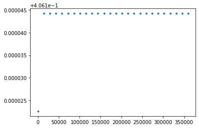